# Tipologia y ciclo de vida de los datos - PRA2

### 3.2.2 Regresion lineal

Con este grupo de datos y las relaciones observadas tanto en las gráficas de caja como los datos de correlación estimaremos por mínimos cuadrados ordinarios un modelo lineal que explique la variable “quality”. Vamos a tener en cuenta todas las variables que tengan un valor de correlación superior a 0.2, tanto positivas como negativas.

```r
# Creamos el modelo
modelo <- (lm(formula = quality ~
                alcohol +
                sulphates +
                citric.acid +
                volatile.acidity +
                density +
                chlorides,
                data = datos_clean))
summary(modelo)
```

```
##
## Call:
## lm(formula = quality ~ alcohol + sulphates + citric.acid + volatile.acidity +
##     density + chlorides, data = datos_clean)
##
## Residuals:
##      Min       1Q   Median       3Q      Max
## -1.97648 -0.37168 -0.07193  0.44973  2.02904
##
## Coefficients:
##                   Estimate Std. Error t value Pr(>|t|)
## (Intercept)       23.03247   18.25796   1.262    0.207
## alcohol            0.29089    0.02724  10.677  < 2e-16 ***
## sulphates          1.79791    0.19154   9.387  < 2e-16 ***
## citric.acid       -0.09148    0.15907  -0.575    0.565
## volatile.acidity  -0.88556    0.16137  -5.488 5.19e-08 ***
## density          -21.06388   18.25105  -1.154    0.249
## chlorides         -0.95104    1.45430  -0.654    0.513
## ---
## Signif. codes:  0 '***' 0.001 '**' 0.01 '*' 0.05 '.' 0.1 ' ' 1
##
## Residual standard error: 0.6119 on 973 degrees of freedom
## Multiple R-squared:  0.3803, Adjusted R-squared:  0.3765
## F-statistic: 99.52 on 6 and 973 DF,  p-value: < 2.2e-16
```

```r
# Creamos un modelo reducido
modelo_reducido <- (lm(formula = quality ~
                                 alcohol +
                                 sulphates +
                                 volatile.acidity,
                                 data = datos_clean))
summary(modelo_reducido)
```

```
##
## Call:
## lm(formula = quality ~ alcohol + sulphates + volatile.acidity,
##     data = datos_clean)
##
## Residuals:
##      Min       1Q   Median       3Q      Max
## -2.04685 -0.37443 -0.07396  0.45867  1.99324
##
## Coefficients:
##                  Estimate Std. Error t value Pr(>|t|)
## (Intercept)       1.70257    0.24707   6.891 9.93e-12 ***
## alcohol           0.31658    0.02068  15.309  < 2e-16 ***
## sulphates         1.70920    0.18341   9.319  < 2e-16 ***
## volatile.acidity -0.82619    0.12447  -6.638 5.28e-11 ***
## ---
## Signif. codes:  0 '***' 0.001 '**' 0.01 '*' 0.05 '.' 0.1 ' ' 1
##
## Residual standard error: 0.6123 on 976 degrees of freedom
## Multiple R-squared:  0.3775, Adjusted R-squared:  0.3755
## F-statistic: 197.3 on 3 and 976 DF,  p-value: < 2.2e-16
```

Como podemos observar, todas las variables utilizadas se consideran significativas, y la exclusión de las tres variables no significativas respecto al modelo anterior no ha supuesto una merma relevante en la calidad del modelo, con estas tres variables podemos explicar el 37.55% de la clasificación de quality. Finalmente, analizamos estadísticamente el modelo.

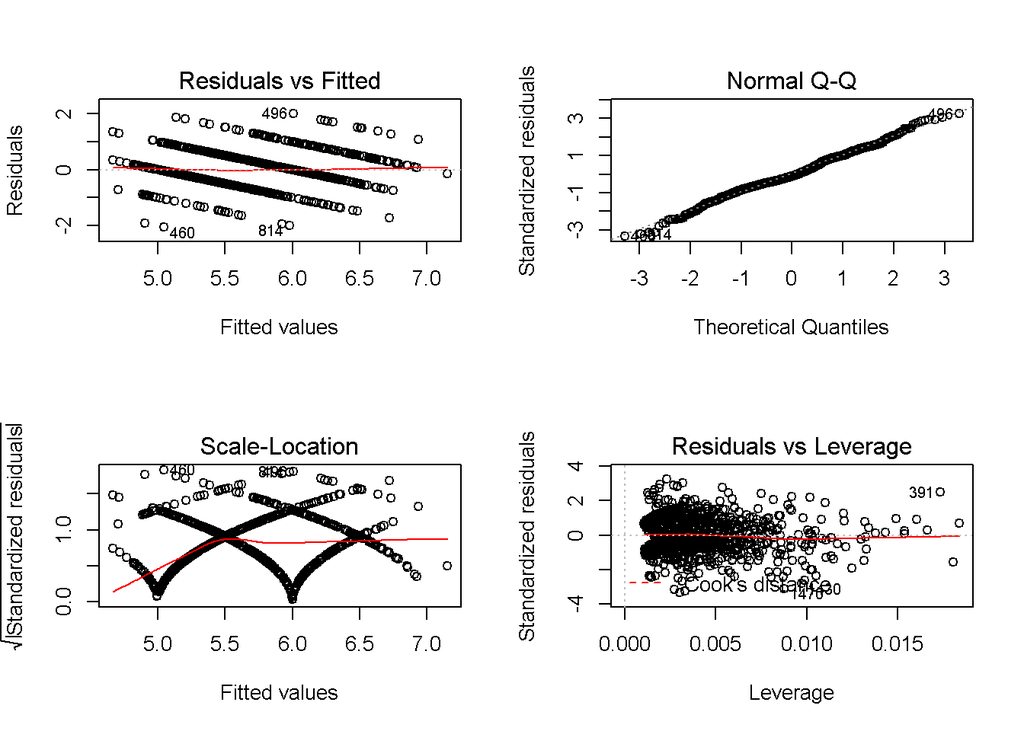

```r
par(mfrow=c(2,2))
plot(modelo_reducido)
```